# Final Project

Jonathan Palada Rosal

2022-05-30

## Introduction

The purpose of this project is to generate a model that will be able to predict the price of an electric vehicle based on the features that vehicle comes with.

### Electric Cars

An electric car is a car that does not run on a petrol engine but rather runs on an electric battery. Some benefits to owning an electric car are that the car is quieter, no exhaust emissions, and low maintenance costs. Electric cars are becoming increasingly popular, due to the rise of gas prices, and the advancement in technology. The problem with electric cars before was that they were too expensive, they couldn’t travel far, and there weren’t many places to charge your vehicle. Most electric cars do not suffer from these problems anymore. Therefore, there is more reason to purchase an electric car.

```r
embed_youtube("FDTf2d47P4A")
```

[video not shown]

### How my model can be helpful

This model can be helpful by helping customers choose the features they want in their car and getting an estimated price based on what they chose. Another way they can use the model is if they have a specific budget for their electric car, then they can see what options are available to them.

### Reading in the dataset

```r
electric_cars <- read.csv("ElectricCarData_Clean.csv")
head(electric_cars)
```

```
##         Brand                         Model AccelSec TopSpeed_KmH Range_Km
## 1      Tesla  Model 3 Long Range Dual Motor      4.6          233      450
## 2 Volkswagen                      ID.3 Pure     10.0          160      270
## 3   Polestar                              2      4.7          210      400
## 4        BMW                           iX3       6.8          180      360
## 5      Honda                             e       9.5          145      170
## 6      Lucid                           Air       2.8          250      610
##   Efficiency_WhKm FastCharge_KmH RapidCharge PowerTrain   PlugType BodyStyle
## 1             161            940         Yes        AWD Type 2 CCS     Sedan
## 2             167            250         Yes        RWD Type 2 CCS Hatchback
## 3             181            620         Yes        AWD Type 2 CCS  Liftback
## 4             206            560         Yes        RWD Type 2 CCS       SUV
## 5             168            190         Yes        RWD Type 2 CCS Hatchback
## 6             180            620         Yes        AWD Type 2 CCS     Sedan
##   Segment Seats PriceEuro
## 1       D     5     55480
## 2       C     5     30000
## 3       D     5     56440
## 4       D     5     68040
## 5       B     4     32997
## 6       F     5    105000
```

```r
# Cleaning the names and deselecting the variable "segment"
electric_cars$FastCharge_KmH <- as.numeric(electric_cars$FastCharge_KmH)
electric_cars$AccelSec <- as.numeric(electric_cars$AccelSec)
electric_cars <- electric_cars %>%
  clean_names()
head(electric_cars) # names are cleaned up
```

```
##         brand                         model accel_sec top_speed_km_h range_km
## 1      Tesla  Model 3 Long Range Dual Motor       4.6            233      450
## 2 Volkswagen                      ID.3 Pure      10.0            160      270
## 3   Polestar                              2       4.7            210      400
## 4        BMW                           iX3        6.8            180      360
## 5      Honda                             e        9.5            145      170
## 6      Lucid                           Air        2.8            250      610
##   efficiency_wh_km fast_charge_km_h rapid_charge power_train  plug_type
## 1              161              940          Yes         AWD Type 2 CCS
## 2              167              250          Yes         RWD Type 2 CCS
## 3              181              620          Yes         AWD Type 2 CCS
## 4              206              560          Yes         RWD Type 2 CCS
## 5              168              190          Yes         RWD Type 2 CCS
## 6              180              620          Yes         AWD Type 2 CCS
##   body_style segment seats price_euro
## 1      Sedan       D     5      55480
## 2  Hatchback       C     5      30000
## 3   Liftback       D     5      56440
## 4        SUV       D     5      68040
## 5  Hatchback       B     4      32997
## 6      Sedan       F     5     105000
```

### An overview of the dataset

The dataset I am using is from the website Kaggle. This dataset contains some variables that are important to a customer looking to buy an electric vehicle. The variables in this dataset are as follows - Brand: The brand of the vehicle - Model: The model of the vehicle - AccelSec: The acceleration of the vehicle from 0-100 (km/h) - TopSpeed_KmH: The top speed of the vehicle (km/h) - Range_Km: The range of the vehicle on a full charge (km) - Efficiency_WhKm: The efficiency of the electric vehicle in watts per hour per kilometer (wh/km) - FastCharge_KmH: The charging rate of an electric car in kilometer per hour (km/h) - RapidCharge: If the car has the option of rapidcharge. Rapidcharge is a faster charge rate than the typical charging rate - PowerTrain: If the car has front, rear, or all-wheel drive - PlugType: The type of plug the electric vehicle uses - BodyStyle: The type of body style or car style the vehicle is - Segment: The market segment the car is in - Seats: The amount of seats the vehicle holds - PriceEuro: The price of the vehicle before any tax incentives

## Important factors to Customers

As a person who’s family currently owns an electric car, there are some key aspects that are important to a customer when finding the right electric car for them. Depending on a person’s environment, needs, and wants, will help decide on what electric car would be perfect for them.

### Acceleration & Top Speed

The acceleration of a vehicle could be important to customers who live in an environment with many hills and inclines. Another reason why a customer may be interested in a higher acceleration car is if they want a more “exciting” drive. A car with high acceleration will give the vehicle a more sportier feel.

The top speed of a vehicle could be important to a customer if they have a place where they could take advantage of the car’s top speed. A place could be the Autobahn. The Autobahn is a freeway in Germany does not have any speed limits in some area. So a high top speed vehicle would benefit here.

[figure not shown]

Fig 1. Autobahn, map of freeway in Germany

Top Speed and Acceleration usually seem to have some type of correlation with each other in gas powered vehicles. Usually if a car has a high top speed, they usually have a lower 0-100kmh time.

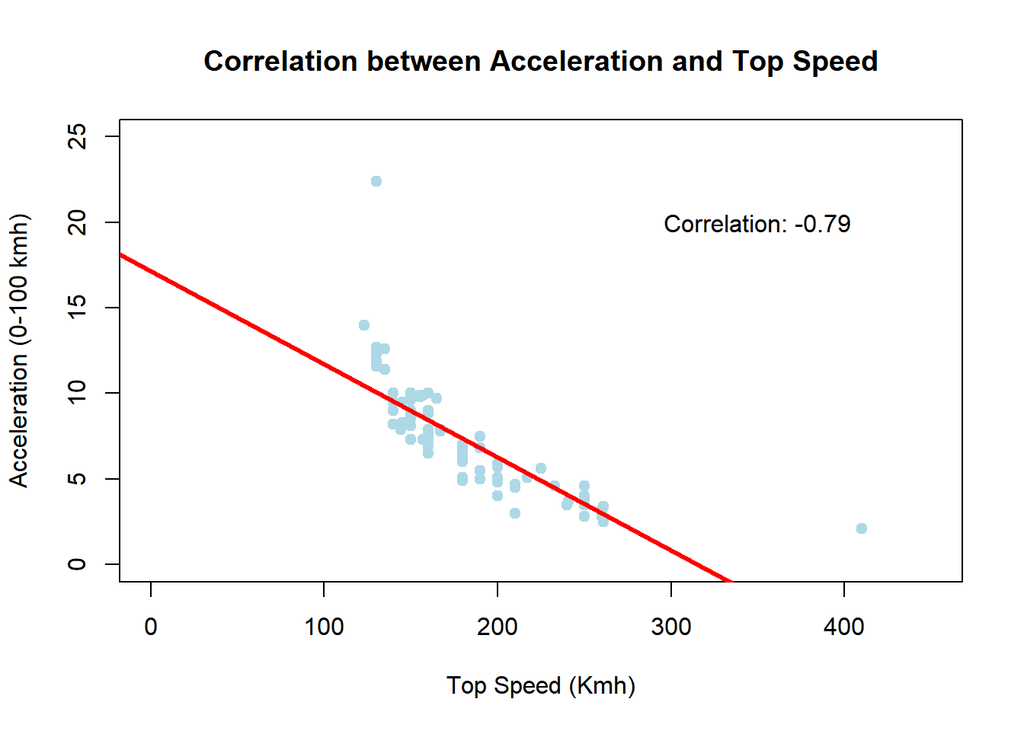

```r
plot(electric_cars$top_speed_km_h,electric_cars$accel_sec,  pch = 19, col = "lightblue", xlab="Top Speed (Kmh)", ylab = "Acceleration (0-100 kmh)", main = "Correlation between Acceleration and Top Speed", xlim = c(0,450), ylim = c(0, 25),)
# Regression line
abline(lm(electric_cars$accel_sec ~ electric_cars$top_speed_km_h), col = "red", lwd = 3)
# Pearson correlation
text(paste("Correlation:", round(cor(electric_cars$top_speed_km_h, electric_cars$accel_sec), 2)), x = 350, y = 20)
```

Based on the graph we can see that acceleration and top speed have a relatively strong negative correlation. Acceleration and Top Speed have a correlation of -0.79. From this graph we can say that the higher a top speed an electric car has, the lower 0-100kmh time.

### Range, fast charge, and rapid charge.

Out of all the variables of the electric car, I believe this is to be the most important variable of them all. Range tells how far the vehicle can travel before needing to be recharged. Having a shorter range on car can significantly decrease the amount of places the car can travel and how long it will take to get to each destination (due to having to recharge more often). At this period of time (2022), there are not as many charging stations as gas stations. Therefore, it is very important to know where all the nearest charging stations are when traveling, or else it will result in the car running out of electricity.

Going off charging stations, a faster charger would benefit. The benefit of gas cars over electric cars are that for a gas powered car, it takes a few minutes to refill. This is compared to electric cars that may take up to an hour or more to be completely charged. However, some cars have fast charging or even better rapid charging. This can get the electric cars to 80% charge in just 10-15 minutes.

```r
embed_youtube("OpTOKKKGWV8")
```

[video not shown]

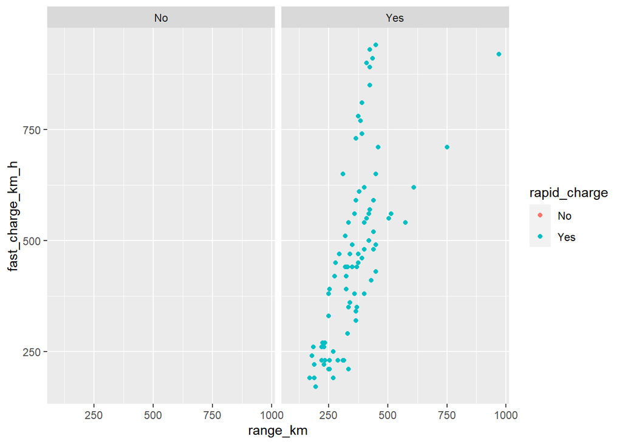

```r
ggplot(electric_cars, aes(x=range_km, y=fast_charge_km_h, colour = rapid_charge)) + geom_point() + facet_wrap( ~ rapid_charge)
```

### Price

Of course price is truly important to customers. An electric car can contain all these cool features, but if the price is completely overpriced then it would not be worth it. Price is a key factor for everything we purchase. We buy things that we feel is worth the price. No matter how good an object it is, we always end up buying that item if the price is reasonable. This is the reason why I decided to make price my response variable in this project.

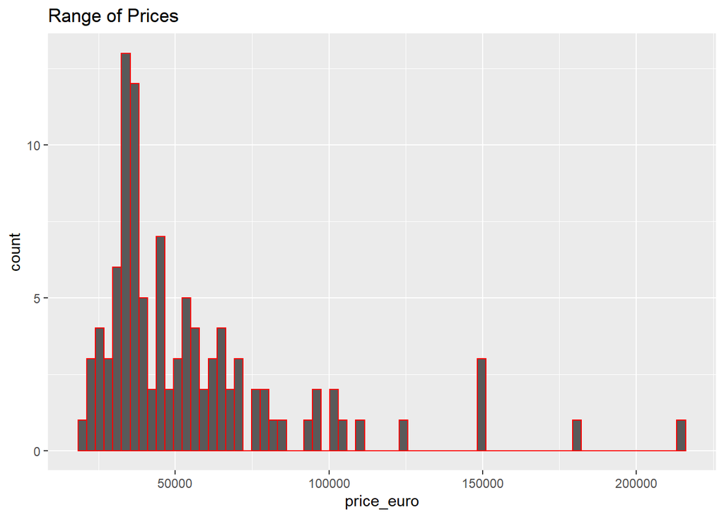

```r
ggplot(electric_cars, aes(price_euro)) +
   geom_histogram(bins = 70, color = "red") +
   labs(title = "Range of Prices")
```

Based on the plot we can say that the price of the electric vehicles from this dataset, mainly ranges from 0 to 80,000. The vehicles that are above this range are most likely luxurious electric vehicles or high-end sport electric sport cars. The cars that are within this range are most likely efficiently friendly vehicles.

## Prepearation for modeling

The following models conducted were done in this order and procedure: 1. Building the model 2. Running the model 3. Analyzing the results of the model

### Splitting the data

```r
electric_cars <- electric_cars %>%
  mutate(brand = factor(brand)) %>%
  mutate(rapid_charge = factor(rapid_charge)) %>%
  mutate(power_train = factor(power_train)) %>%
  mutate(plug_type = factor(plug_type)) %>%
  mutate(body_style = factor(body_style)) %>%
  mutate(segment = factor(segment))
head(electric_cars)
```

```
##         brand                         model accel_sec top_speed_km_h range_km
## 1      Tesla  Model 3 Long Range Dual Motor       4.6            233      450
## 2 Volkswagen                      ID.3 Pure      10.0            160      270
## 3   Polestar                              2       4.7            210      400
## 4        BMW                           iX3        6.8            180      360
## 5      Honda                             e        9.5            145      170
## 6      Lucid                           Air        2.8            250      610
##   efficiency_wh_km fast_charge_km_h rapid_charge power_train  plug_type
## 1              161              940          Yes         AWD Type 2 CCS
## 2              167              250          Yes         RWD Type 2 CCS
## 3              181              620          Yes         AWD Type 2 CCS
## 4              206              560          Yes         RWD Type 2 CCS
## 5              168              190          Yes         RWD Type 2 CCS
## 6              180              620          Yes         AWD Type 2 CCS
##   body_style segment seats price_euro
## 1      Sedan       D     5      55480
## 2  Hatchback       C     5      30000
## 3   Liftback       D     5      56440
## 4        SUV       D     5      68040
## 5  Hatchback       B     4      32997
## 6      Sedan       F     5     105000
```

```r
set.seed(12)
ec_split <- electric_cars %>%
  initial_split(prop = 0.75, strata = "price_euro")

ec_train <- training(ec_split)
dim(ec_train) #75
```

```
## [1] 75 14
```

```r
ec_test <- testing(ec_split)
dim(ec_test) #28
```

```
## [1] 28 14
```

### Finding correlations

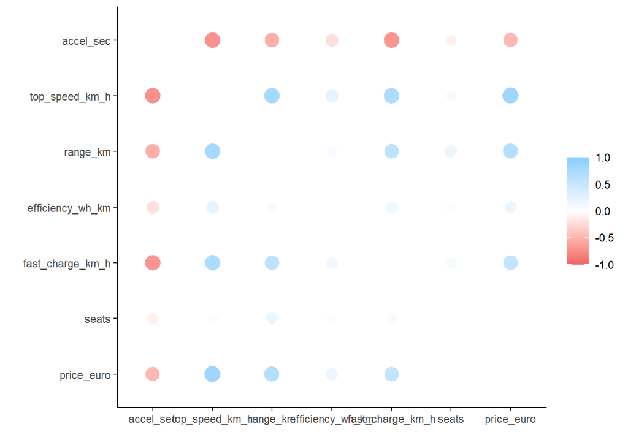

```r
cor_ec <- ec_train %>%
  select_if(is.numeric) %>%
  correlate()
rplot(cor_ec)
```

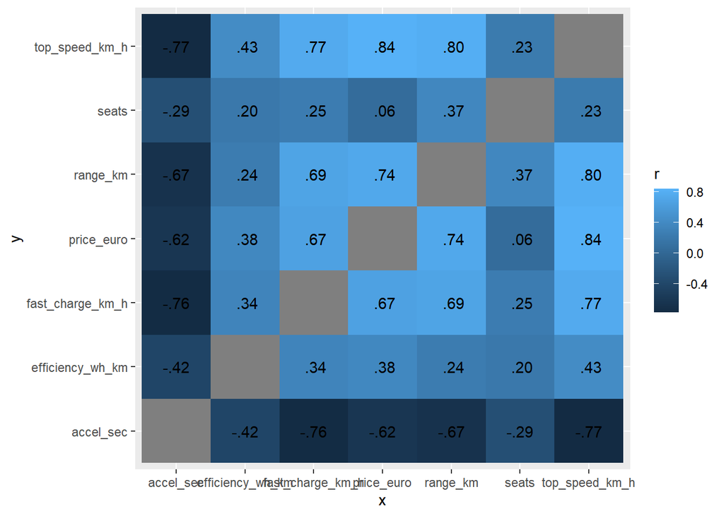

```r
cor_ec %>%
  stretch() %>%
  ggplot(aes(x,y,fill = r)) + geom_tile() + geom_text(aes(label = as.character(fashion(r))))
```

Based on the correlation plot we can see that accel_sec has strong negative correlations with the variables: top_speed_km_h, range_km, price_euro. Top_speed_km_h has strong positive correlations with the variables: range_km, price_euro. The last correlation that is relative noting is the positive correlation between range_km and price_euro.

### Making the recipe and folds

```r
ec_recipe <- recipe(price_euro ~ accel_sec + top_speed_km_h + range_km + efficiency_wh_km + fast_charge_km_h + rapid_charge + power_train + plug_type + body_style + segment + seats, data = ec_train) %>%
  step_dummy(all_nominal_predictors()) %>%
  step_scale(all_predictors()) %>%
  step_normalize(all_predictors()) %>%
  step_novel(all_nominal_predictors()) %>%
  step_zv(all_nominal_predictors())


ec_folds <- vfold_cv(ec_train, strata = price_euro, v = 10, repeats = 5)
```

## The models

### Ridge Regression

```r
#Ridge Regression

ridge_spec <- linear_reg(penalty = tune(), mixture = 0) %>%
  set_mode("regression") %>%
  set_engine("glmnet")

ridge_workflow <- workflow() %>%
  add_recipe(ec_recipe) %>%
  add_model(ridge_spec)

set.seed(12)

penalty_grid <- grid_regular(penalty(range = c(1, 11)), levels = 50)
penalty_grid
```

```
## # A tibble: 50 x 1
##    penalty
##      <dbl>
##  1    10
##  2    16.0
##  3    25.6
##  4    40.9
##  5    65.5
##  6   105.
##  7   168.
##  8   268.
##  9   429.
## 10   687.
## # ... with 40 more rows
```

```r
tune_res <- tune_grid(
  ridge_workflow,
  resamples = ec_folds,
  grid = penalty_grid
)
tune_res
```

```
## # Tuning results
## # 10-fold cross-validation repeated 5 times using stratification
## # A tibble: 50 x 5
##    splits         id      id2    .metrics           .notes
##    <list>         <chr>   <chr>  <list>             <list>
##  1 <split [66/9]> Repeat1 Fold01 <tibble [100 x 5]> <tibble [1 x 3]>
##  2 <split [66/9]> Repeat1 Fold02 <tibble [100 x 5]> <tibble [1 x 3]>
##  3 <split [66/9]> Repeat1 Fold03 <tibble [100 x 5]> <tibble [1 x 3]>
##  4 <split [66/9]> Repeat1 Fold04 <tibble [100 x 5]> <tibble [1 x 3]>
##  5 <split [66/9]> Repeat1 Fold05 <tibble [100 x 5]> <tibble [1 x 3]>
##  6 <split [69/6]> Repeat1 Fold06 <tibble [100 x 5]> <tibble [1 x 3]>
##  7 <split [69/6]> Repeat1 Fold07 <tibble [100 x 5]> <tibble [1 x 3]>
##  8 <split [69/6]> Repeat1 Fold08 <tibble [100 x 5]> <tibble [1 x 3]>
##  9 <split [69/6]> Repeat1 Fold09 <tibble [100 x 5]> <tibble [1 x 3]>
## 10 <split [69/6]> Repeat1 Fold10 <tibble [100 x 5]> <tibble [1 x 3]>
## # ... with 40 more rows
##
## There were issues with some computations:
##
##   - Warning(s) x50: A correlation computation is required, but `estimate` is constant...
##
## Use `collect_notes(object)` for more information.
```

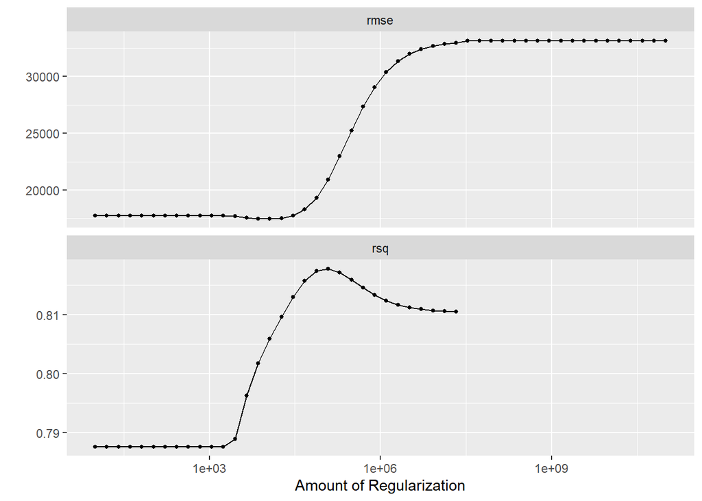

```r
autoplot(tune_res)
```

```r
collect_metrics(tune_res)
```

```
## # A tibble: 100 x 7
##    penalty .metric .estimator      mean     n   std_err .config
##      <dbl> <chr>   <chr>          <dbl> <int>     <dbl> <chr>
##  1    10   rmse    standard   17756.       50 1878.     Preprocessor1_Model01
##  2    10   rsq     standard       0.788    50    0.0292 Preprocessor1_Model01
##  3    16.0 rmse    standard   17756.       50 1878.     Preprocessor1_Model02
##  4    16.0 rsq     standard       0.788    50    0.0292 Preprocessor1_Model02
##  5    25.6 rmse    standard   17756.       50 1878.     Preprocessor1_Model03
##  6    25.6 rsq     standard       0.788    50    0.0292 Preprocessor1_Model03
##  7    40.9 rmse    standard   17756.       50 1878.     Preprocessor1_Model04
##  8    40.9 rsq     standard       0.788    50    0.0292 Preprocessor1_Model04
##  9    65.5 rmse    standard   17756.       50 1878.     Preprocessor1_Model05
## 10    65.5 rsq     standard       0.788    50    0.0292 Preprocessor1_Model05
## # ... with 90 more rows
```

```r
best_penalty <- select_best(tune_res, metric = "rsq")
best_penalty
```

```
## # A tibble: 1 x 2
##   penalty .config
##     <dbl> <chr>
## 1 120679. Preprocessor1_Model21
```

```r
ridge_final <- finalize_workflow(ridge_workflow, best_penalty)
ridge_final_fit <- fit(ridge_final, data = ec_train)

ec_train_res1 <- predict(ridge_final_fit, new_data = ec_test %>% dplyr::select(-price_euro))
ec_train_res1 <- bind_cols(ec_train_res1, ec_test %>% dplyr::select(price_euro))
ec_train_res1 %>%
  head()
```

```
## # A tibble: 6 x 2
##    .pred price_euro
##    <dbl>      <int>
## 1 74165.      55480
## 2 43343.      30000
## 3 56314.      68040
## 4 40008.      31900
## 5 64861.      46380
## 6 49787.      40795
```

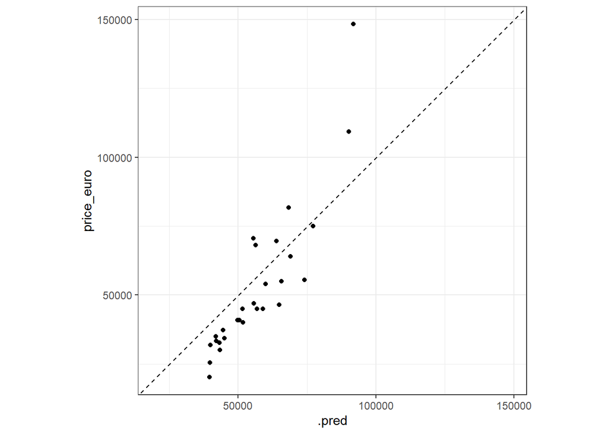

```r
ec_train_res1 %>%
  ggplot(aes(x=.pred, y=price_euro)) + geom_point(alpha = 1) + geom_abline(lty = 2) + theme_bw() + coord_obs_pred()
```

```r
augment(ridge_final_fit, new_data = ec_test) %>%
  rsq(truth = price_euro, estimate = .pred)
```

```
## # A tibble: 1 x 3
##   .metric .estimator .estimate
##   <chr>   <chr>          <dbl>
## 1 rsq     standard       0.796
```

### Lasso Regression

```r
#Lasso Regression

lasso_spec <-
  linear_reg(penalty = tune(), mixture = 1) %>%
  set_mode("regression") %>%
  set_engine("glmnet")

lasso_workflow <- workflow() %>%
  add_recipe(ec_recipe) %>%
  add_model(lasso_spec)

set.seed(12)

tune_res_lasso <- tune_grid(
  lasso_workflow,
  resamples = ec_folds,
  grid = penalty_grid
)
tune_res_lasso
```

```
## # Tuning results
## # 10-fold cross-validation repeated 5 times using stratification
## # A tibble: 50 x 5
##    splits         id      id2    .metrics           .notes
##    <list>         <chr>   <chr>  <list>             <list>
##  1 <split [66/9]> Repeat1 Fold01 <tibble [100 x 5]> <tibble [1 x 3]>
##  2 <split [66/9]> Repeat1 Fold02 <tibble [100 x 5]> <tibble [1 x 3]>
##  3 <split [66/9]> Repeat1 Fold03 <tibble [100 x 5]> <tibble [1 x 3]>
##  4 <split [66/9]> Repeat1 Fold04 <tibble [100 x 5]> <tibble [1 x 3]>
##  5 <split [66/9]> Repeat1 Fold05 <tibble [100 x 5]> <tibble [1 x 3]>
##  6 <split [69/6]> Repeat1 Fold06 <tibble [100 x 5]> <tibble [1 x 3]>
##  7 <split [69/6]> Repeat1 Fold07 <tibble [100 x 5]> <tibble [1 x 3]>
##  8 <split [69/6]> Repeat1 Fold08 <tibble [100 x 5]> <tibble [1 x 3]>
##  9 <split [69/6]> Repeat1 Fold09 <tibble [100 x 5]> <tibble [1 x 3]>
## 10 <split [69/6]> Repeat1 Fold10 <tibble [100 x 5]> <tibble [1 x 3]>
## # ... with 40 more rows
##
## There were issues with some computations:
##
##   - Warning(s) x50: A correlation computation is required, but `estimate` is constant...
##
## Use `collect_notes(object)` for more information.
```

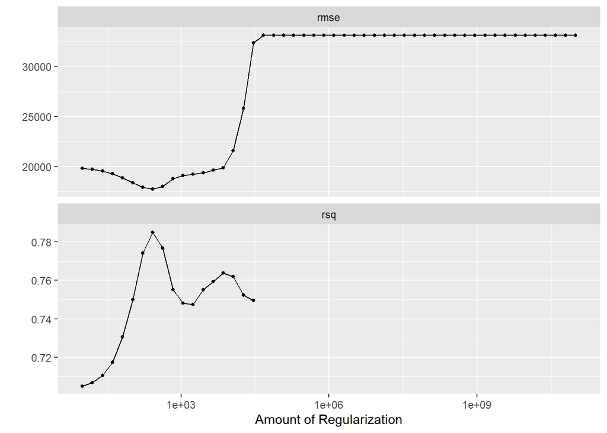

```r
autoplot(tune_res_lasso)
```

```r
collect_metrics(tune_res_lasso)
```

```
## # A tibble: 100 x 7
##    penalty .metric .estimator      mean     n   std_err .config
##      <dbl> <chr>   <chr>          <dbl> <int>     <dbl> <chr>
##  1    10   rmse    standard   19809.       50 2305.     Preprocessor1_Model01
##  2    10   rsq     standard       0.705    50    0.0446 Preprocessor1_Model01
##  3    16.0 rmse    standard   19708.       50 2295.     Preprocessor1_Model02
##  4    16.0 rsq     standard       0.707    50    0.0442 Preprocessor1_Model02
##  5    25.6 rmse    standard   19544.       50 2279.     Preprocessor1_Model03
##  6    25.6 rsq     standard       0.710    50    0.0436 Preprocessor1_Model03
##  7    40.9 rmse    standard   19278.       50 2252.     Preprocessor1_Model04
##  8    40.9 rsq     standard       0.717    50    0.0425 Preprocessor1_Model04
##  9    65.5 rmse    standard   18858.       50 2200.     Preprocessor1_Model05
## 10    65.5 rsq     standard       0.731    50    0.0403 Preprocessor1_Model05
## # ... with 90 more rows
```

```r
best_penalty_lasso <- select_best(tune_res_lasso, metric = "rsq")

lasso_final <- finalize_workflow(lasso_workflow, best_penalty_lasso)
lasso_final_fit <- fit(lasso_final, data = ec_train)

ec_train_res2 <- predict(lasso_final_fit, new_data = ec_test %>% dplyr::select(-price_euro))
ec_train_res2 <- bind_cols(ec_train_res2, ec_test %>% dplyr::select(price_euro))
ec_train_res2 %>%
  head()
```

```
## # A tibble: 6 x 2
##    .pred price_euro
##    <dbl>      <int>
## 1 55988.      55480
## 2 35484.      30000
## 3 55102.      68040
## 4 31469.      31900
## 5 44276.      46380
## 6 35753.      40795
```

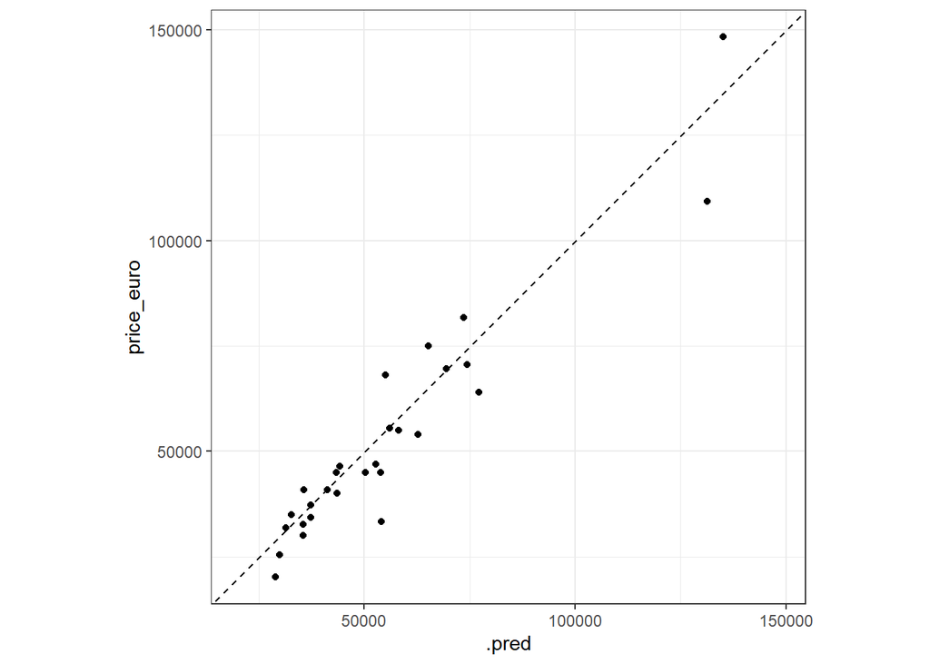

```r
ec_train_res2 %>%
  ggplot(aes(x=.pred, y=price_euro)) + geom_point(alpha=1) + geom_abline(lty = 2) + theme_bw() + coord_obs_pred()
```

```r
augment(lasso_final_fit, new_data = ec_test) %>%
  rsq(truth = price_euro, estimate = .pred)
```

```
## # A tibble: 1 x 3
##   .metric .estimator .estimate
##   <chr>   <chr>          <dbl>
## 1 rsq     standard       0.905
```

### Boosted Model

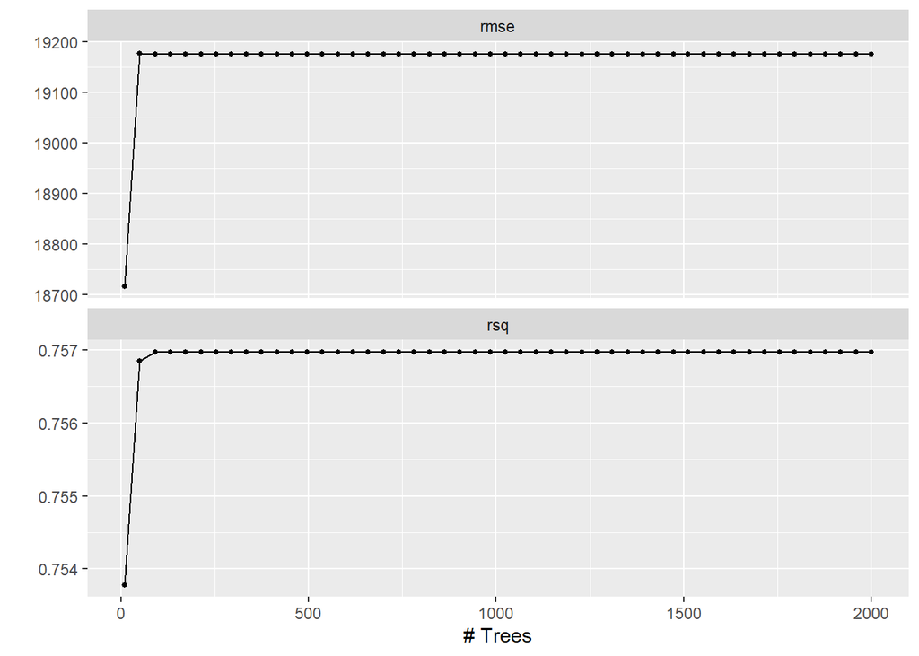

```r
boost_spec <- boost_tree() %>%
  set_engine("xgboost") %>%
  set_mode("regression")

boost_wf <- workflow() %>%
  add_model(boost_spec %>%
  set_args(trees = tune())) %>%
  add_recipe(ec_recipe)

set.seed(12)

boost_grid <- grid_regular(trees(range = c(10, 2000)), levels = 50)

boost_tune_res <- tune_grid(
  boost_wf,
  resamples = ec_folds,
  grid = boost_grid,
)
autoplot(boost_tune_res)
```

```r
collect_metrics(boost_tune_res) %>%
  arrange(-mean) %>%
  head()
```

```
## # A tibble: 6 x 7
##   trees .metric .estimator   mean     n std_err .config
##   <int> <chr>   <chr>       <dbl> <int>   <dbl> <chr>
## 1    50 rmse    standard   19178.    50   2152. Preprocessor1_Model02
## 2    91 rmse    standard   19176.    50   2151. Preprocessor1_Model03
## 3   131 rmse    standard   19176.    50   2151. Preprocessor1_Model04
## 4   172 rmse    standard   19176.    50   2151. Preprocessor1_Model05
## 5   213 rmse    standard   19176.    50   2151. Preprocessor1_Model06
## 6   253 rmse    standard   19176.    50   2151. Preprocessor1_Model07
```

```r
best_boost_final <- select_best(boost_tune_res)
best_boost_final_model <- finalize_workflow(boost_wf, best_boost_final)
best_boost_final_model_fit <- fit(best_boost_final_model, data = ec_train)

ec_train_res4 <- predict(best_boost_final_model_fit, new_data = ec_test %>% dplyr::select(-price_euro))
ec_train_res4 <- bind_cols(ec_train_res4, ec_test %>% dplyr::select(price_euro))
ec_train_res4 %>%
  head()
```

```
## # A tibble: 6 x 2
##    .pred price_euro
##    <dbl>      <int>
## 1 51698.      55480
## 2 33604.      30000
## 3 55283.      68040
## 4 33153.      31900
## 5 39800.      46380
## 6 35191.      40795
```

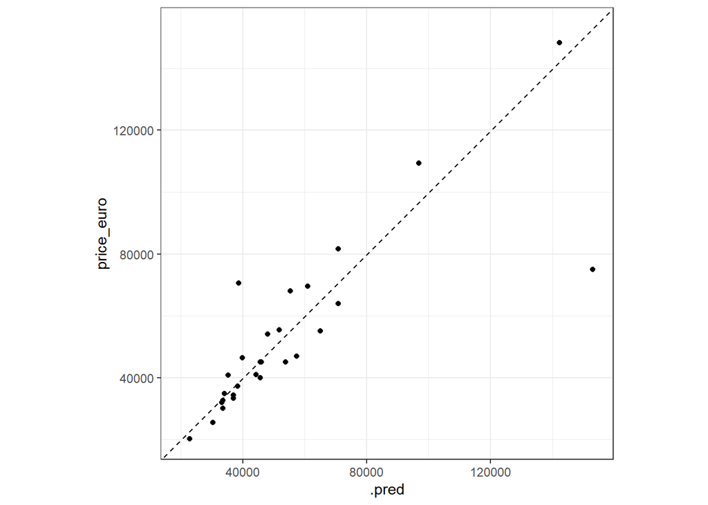

```r
ec_train_res4 %>%
  ggplot(aes(x=.pred, y=price_euro)) + geom_point(alpha=1) + geom_abline(lty = 2) + theme_bw() + coord_obs_pred()
```

```r
augment(best_boost_final_model_fit, new_data = ec_test) %>%
  rsq(truth = price_euro, estimate = .pred)
```

```
## # A tibble: 1 x 3
##   .metric .estimator .estimate
##   <chr>   <chr>          <dbl>
## 1 rsq     standard       0.681
```

### Tree model

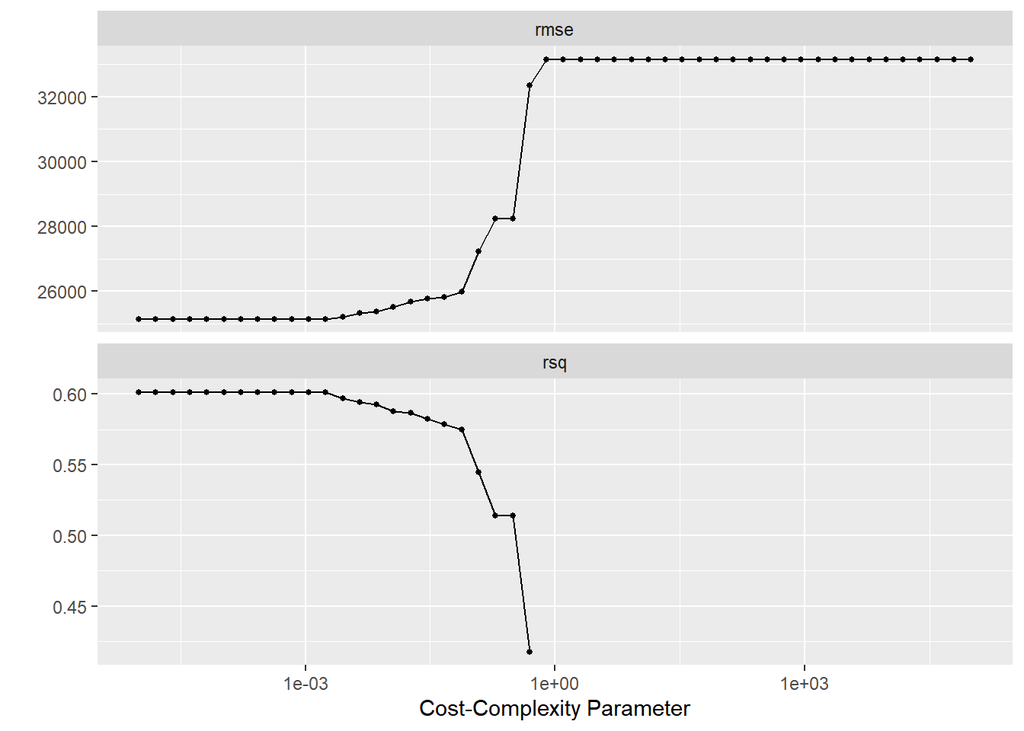

```r
tree_spec <-decision_tree() %>%
  set_engine("rpart")

class_tree_spec <- tree_spec %>%
  set_mode("regression")

class_tree_wf <- workflow() %>%
  add_model(class_tree_spec %>% set_args(cost_complexity = tune())) %>%
  add_recipe(ec_recipe)

set.seed(12)

param_grid <- grid_regular(cost_complexity(range = c(-5, 5)), levels = 50)

tune_res_tree <- tune_grid(
  class_tree_wf,
  resamples = ec_folds,
  grid = param_grid,
)
autoplot(tune_res_tree)
```

```r
tree_roc_auc <- collect_metrics(tune_res_tree) %>%
  arrange(-mean) %>%
  head()
tree_roc_auc
```

```
## # A tibble: 6 x 7
##   cost_complexity .metric .estimator   mean     n std_err .config
##             <dbl> <chr>   <chr>       <dbl> <int>   <dbl> <chr>
## 1           0.791 rmse    standard   33154.    50   1921. Preprocessor1_Model25
## 2           1.26  rmse    standard   33154.    50   1921. Preprocessor1_Model26
## 3           2.02  rmse    standard   33154.    50   1921. Preprocessor1_Model27
## 4           3.24  rmse    standard   33154.    50   1921. Preprocessor1_Model28
## 5           5.18  rmse    standard   33154.    50   1921. Preprocessor1_Model29
## 6           8.29  rmse    standard   33154.    50   1921. Preprocessor1_Model30
```

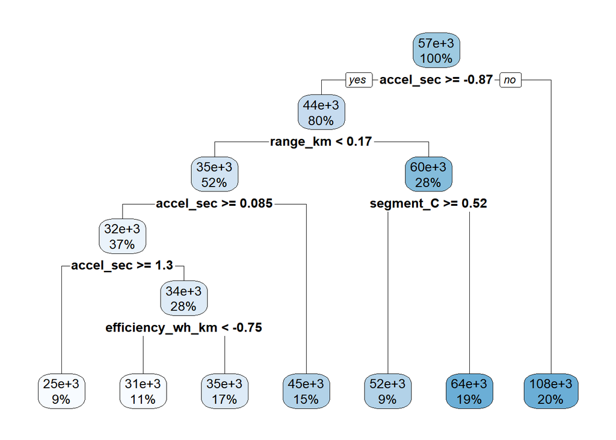

```r
best_complexity <- select_best(tune_res_tree)
class_tree_final <- finalize_workflow(class_tree_wf, best_complexity)
class_tree_final_fit <- fit(class_tree_final, data = ec_train)

class_tree_final_fit %>%
  extract_fit_engine() %>%
  rpart.plot()
```

```r
ec_train_res3 <- predict(class_tree_final_fit, new_data = ec_test %>% dplyr::select(-price_euro))
ec_train_res3 <- bind_cols(ec_train_res3, ec_test %>% dplyr::select(price_euro))
ec_train_res3 %>%
  head()
```

```
## # A tibble: 6 x 2
##     .pred price_euro
##     <dbl>      <int>
## 1 108442.      55480
## 2  35266.      30000
## 3  64206.      68040
## 4  35266.      31900
## 5  44868.      46380
## 6  64206.      40795
```

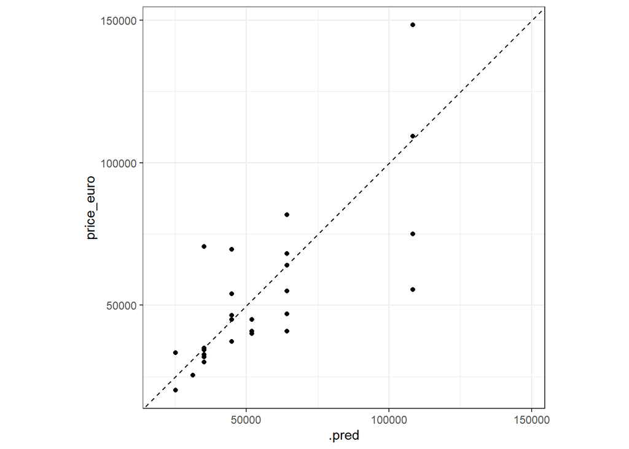

```r
ec_train_res3 %>%
  ggplot(aes(x=.pred, y=price_euro)) + geom_point(alpha=1) + geom_abline(lty = 2) + theme_bw() + coord_obs_pred()
```

```r
augment(class_tree_final_fit, new_data = ec_test) %>%
  rsq(truth = price_euro, estimate = .pred)
```

```
## # A tibble: 1 x 3
##   .metric .estimator .estimate
##   <chr>   <chr>          <dbl>
## 1 rsq     standard       0.569
```